# BMI versus Insurance Charge in R

```r
library(tidyverse)
setwd('/Users/ridhiasnani/Downloads')
insurance_dataset <- read_csv("Medical_Cost.csv")
head(insurance_dataset)
```

```
## # A tibble: 6 × 7
##     age sex      bmi children smoker region    charges
##   <dbl> <chr>  <dbl>    <dbl> <chr>  <chr>       <dbl>
## 1    19 female  27.9        0 yes    southwest  16885.
## 2    18 male    33.8        1 no     southeast   1726.
## 3    28 male    33          3 no     southeast   4449.
## 4    33 male    22.7        0 no     northwest  21984.
## 5    32 male    28.9        0 no     northwest   3867.
## 6    31 female  25.7        0 no     southeast   3757.
```

### Exploratory Data Analysis:

To explore the relationship between BMI and insurance charges, we can use a scatter plot to visualize the two variables.

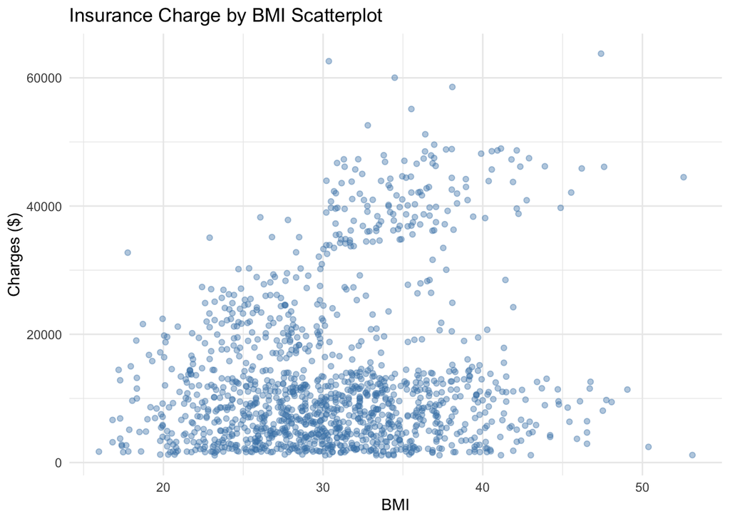

```r
insurance_dataset %>%
  ggplot(aes(bmi, charges)) +
  geom_point(alpha = 0.4, color = "steelblue") +
  labs(
    title = "Insurance Charge by BMI Scatterplot",
    x = "BMI",
    y = "Charges ($)"
  ) +
  theme_minimal()
```

Ihe relationship observed generally shows an upward positive trend. Since there are two clusters of points in the scatterplot, there could be another factor besides BMI impacting a difference in insurance charge for individuals.

We can test these factors by grouping the individuals and comparing their mean average charges. View tables below.

```r
insurance_dataset %>% group_by(smoker) %>% summarise(average_charges = mean(charges))
```

```
## # A tibble: 2 × 2
##   smoker average_charges
##   <chr>            <dbl>
## 1 no               8434.
## 2 yes             32050.
```

```r
insurance_dataset %>% group_by(region) %>% summarise(average_charges = mean(charges))
```

```
## # A tibble: 4 × 2
##   region    average_charges
##   <chr>               <dbl>
## 1 northeast          13406.
## 2 northwest          12418.
## 3 southeast          14735.
## 4 southwest          12347.
```

```r
insurance_dataset %>% group_by(sex) %>% summarise(average_charges = mean(charges))
```

```
## # A tibble: 2 × 2
##   sex    average_charges
##   <chr>            <dbl>
## 1 female          12570.
## 2 male            13957.
```

Viewing the tables above, the smoking factor displays the most significant difference in average insurance charges, compared to other factors.

### Null and Alternative Hypothesis

As a result, we can set the following null and alternative hypotheses to test:

H_0: The slope of the true line between BMI and Charges is 0; there is no linear relationship between the two variables. The slope of true line is the same for smokers versus non-smokers.

H_A: The slope of the true line between BMI and Charges is not 0; there is a linear relationship between the two variables. The slope of the true line is different between smokers and non-smokers.

Since we are only given one sample data, we can find the slopes of multiple boostrapped samples and the resulting 95% confidence interval for the population slope.

### Bootstrapping the Dataset

```r
bootstrap_function <- function(dataset,x,y,seed = NULL) {
  if (!is.null(seed)) set.seed(seed)
  n = nrow(dataset)
  indices = sample(1:n, size = n, replace = TRUE)
  bootstrap_sample = dataset[indices,]
  return(bootstrap_sample)
}
slope <- function(x,y) {
  cor(x,y)*(sd(y)/sd(x))
}
#example of boostrapped sample
head(bootstrap_function(insurance_dataset,insurance_dataset$bmi,insurance$charges))
```

```
## # A tibble: 6 × 7
##     age sex      bmi children smoker region    charges
##   <dbl> <chr>  <dbl>    <dbl> <chr>  <chr>       <dbl>
## 1    54 male    32.8        0 no     northeast  10435.
## 2    45 male    30.5        2 no     northwest   8413.
## 3    27 male    29.2        0 yes    southeast  18246.
## 4    22 female  36          0 no     southwest   2167.
## 5    53 female  37.4        1 no     northwest  10960.
## 6    53 male    29.5        0 no     southeast   9488.
```

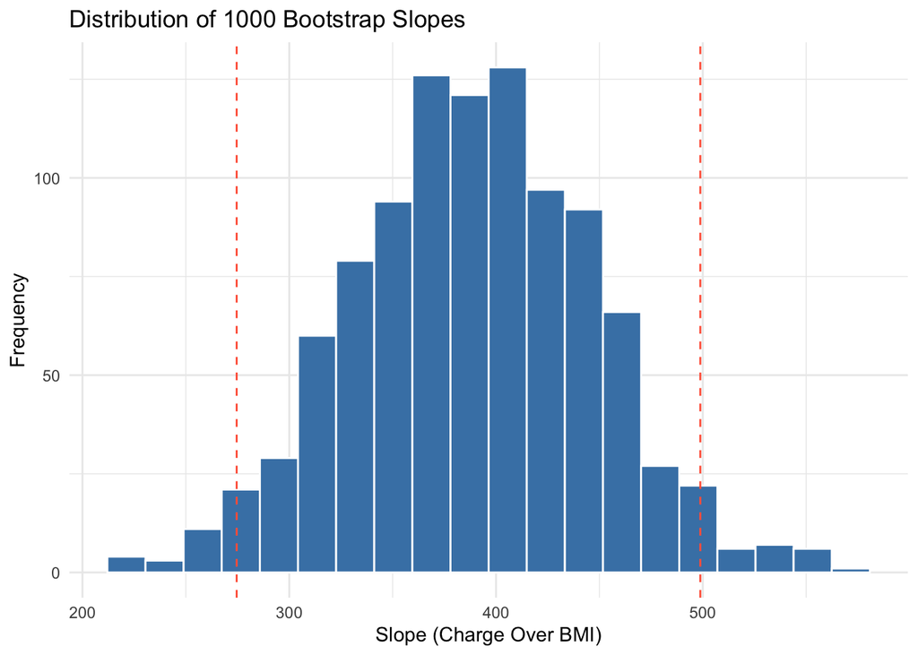

```r
all_slopes <- function(dataset, x, y, repetitions, seed = NULL) {
  if (!is.null(seed)) set.seed(seed)
  sapply(1:repetitions, function(i) {
    bootstrap_sample <- bootstrap_function(dataset,x,y)
    slope(bootstrap_sample$bmi, bootstrap_sample$charges)
  })
}
slopes_1000 <- all_slopes(insurance_dataset, insurance_dataset$bmi, insurance_dataset$charges,1000)

data.frame(slopes_1000) %>%
  ggplot(aes(slopes_1000)) +
  geom_histogram(fill = "steelblue", color = "white", bins = 20) +
  geom_vline(xintercept = quantile(slopes_1000, 0.025), linetype = "dashed", color = "tomato") +
  geom_vline(xintercept = quantile(slopes_1000, 0.975),
             linetype = "dashed", color = "tomato") +
  labs(
    title = "Distribution of 1000 Bootstrap Slopes",
    x = "Slope (Charge Over BMI)",
    y = "Frequency"
  ) +
  theme_minimal()
```

```r
quantile(slopes_1000, 0.025)
```

```
##     2.5%
## 274.5709
```

```r
quantile(slopes_1000, 0.975)
```

```
##    97.5%
## 498.7913
```

### Results

Above is the distribution of slopes of charge over bmi for 1000 boostrapped samples. It can be said with 95% confidence that true slope lies between the given 2.5th and 97.5th percentiles of the distribution, shown above.

Since 0 does not fall in the 95% confidence interval, there is enough evidence to reject the null hypothesis that there is no linear relationship between BMI and charges, using a p-value of 0.05.

### Smokers vs. Non-smokers: Bootstrapping

Next, we can use the same approach to test the claim that smokers and non-smokers would have a different value in true slope. We start by finding separate bootstrap samples for smokers versus non-smokers, followed by their resulting 95% CI’s for true slope.

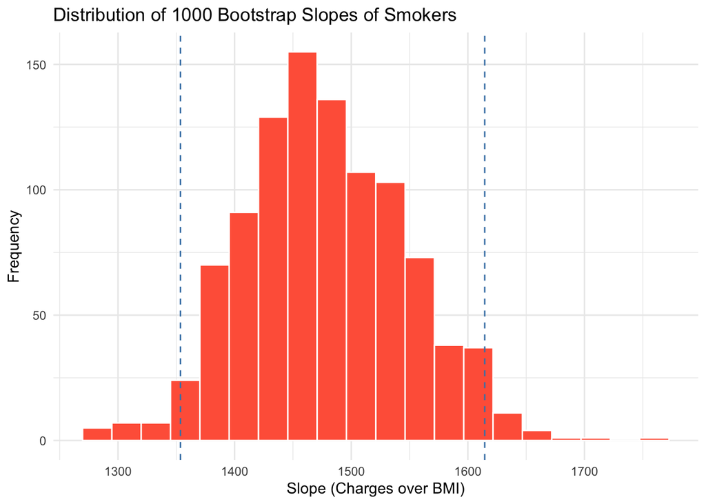

```r
smoker_data <- insurance_dataset %>% filter(smoker == "yes")
nonsmoker_data <- insurance_dataset %>% filter(smoker == "no")

smoker_slopes <- all_slopes(smoker_data,smoker_data$bmi,smoker_data$charges, 1000)
data.frame(smoker_slopes) %>%
  ggplot(aes(smoker_slopes)) +
  geom_histogram(fill = "tomato", color = "white", bins = 20) +
  geom_vline(xintercept = quantile(smoker_slopes, 0.025),
             linetype = "dashed", color = "steelblue") +
  geom_vline(xintercept = quantile(smoker_slopes, 0.975),
             linetype = "dashed", color = "steelblue") +
  labs(title = "Distribution of 1000 Bootstrap Slopes of Smokers",
       x = "Slope (Charges over BMI)", y = "Frequency") +
  theme_minimal()
```

```r
quantile(smoker_slopes, 0.025)
```

```
##     2.5%
## 1353.577
```

```r
quantile(smoker_slopes, 0.975)
```

```
##   97.5%
## 1614.46
```

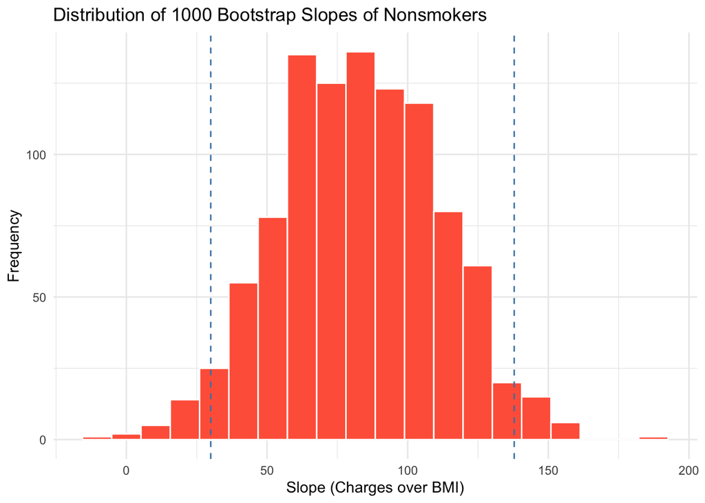

```r
nonsmoker_slopes <- all_slopes(nonsmoker_data, nonsmoker_data$bmi, nonsmoker_data$charges, 1000)
data.frame(nonsmoker_slopes) %>%
  ggplot(aes(nonsmoker_slopes)) +
  geom_histogram(fill = "tomato", color = "white", bins = 20) +
  geom_vline(xintercept = quantile(nonsmoker_slopes, 0.025),
             linetype = "dashed", color = "steelblue") +
  geom_vline(xintercept = quantile(nonsmoker_slopes, 0.975),
             linetype = "dashed", color = "steelblue") +
  labs(title = "Distribution of 1000 Bootstrap Slopes of Nonsmokers",
       x = "Slope (Charges over BMI)", y = "Frequency") +
  theme_minimal()
```

```r
quantile(nonsmoker_slopes, 0.025)
```

```
##     2.5%
## 29.99608
```

```r
quantile(nonsmoker_slopes, 0.975)
```

```
##    97.5%
## 137.8686
```

### Results

The 95% CI for the true slope of smokers (Charge over BMI) is vastly different from that of nonsmokers, showing no overlap. These results provide strong evidence to reject H_0, which suggests the true slope is the same for both nonsmokers and smokers.

## Summary

BMI has a statistically significant positive relationship with insurance charges. Morover, smoking is a critical confounding variable, smokers are expected to pay dramatically higher charges regardless of BMI, and the effect of BMI on charges differs between smokers and non-smokers.

Future work could incorporate additional variables such as age and sex into a multiple regression model for more accurate predictions.